# DA5020 Practicum 3

Group 1: Nishat Mohammad and Victoria Clendaniel

04/09/2024

## Loading Packages

```r
library(dplyr)
library(ggplot2)
library(tidyr)
library(e1071)
library(scales)
library(caret)
library(lubridate)
library(corrplot)
library(psych)
library(FNN)
library(viridis)
library(Metrics)
```

## CRISP-DM: Business Understanding.

This report is intended to support the NYC Taxi and Limousine Commission (TLC) in their quest to evaluate their NYC Green Taxi Trip Records, under the scope of cab driver incentivization (tipping). This report aims to answer these questions and provide insight to TLC leadership.

## 1. CRISP-DM: Data Understanding.

Load the NYC Green Taxi Trip Records data into a data frame or tibble. Data exploration: explore the data to identify any patterns and analyze the relationships between the features and the target variable i.e. tip amount. At a minimum, you should analyze: 1) the distribution, 2) the correlations 3) missing values and 4) outliers — provide supporting visualizations and explain all your steps.  
Tip: remember that you have worked with this dataset in your previous assignments. You are free to reuse any code that support your analysis. Feature selection: identify the features/variables that are good indicators and should be used to predict the tip amount. Note: this step involves selecting a subset of the features that will be used to build the predictive model. If you decide to omit any features/variables ensure that you briefly state the reason.  
Feature engineering: (+10 bonus points): create a new feature and analyze its effect on the target variable (e.g. the tip amount). Ensure that you calculate the correlation coefficient and also use visualizations to support your analysis. Summarize your findings and determine if the new feature is a good indicator to predict the tip amount. If it is, ensure that you include it in your model. If it is not a good indicator, explain the reason. NOTE: If you attempt this bonus question, ensure that you create a meaningful feature (and nothing arbitrary). If you are unable to think about something meaningful, do not become fixated on this. There is another bonus question that you can attempt later in the practicum.

### 1.1. Loading data.

```r
# Load the 2018 data
file <- "2018GreenTaxiTripData1.csv"
tripdata_df <- as.data.frame(read.csv(file))
```

The data 2018 data has been loaded through the csv file using the `read.csv()` function and a data frame has been created in a variable called `tripdata_df`.

### 1.2. Data Exploration.

```r
# Look at 2018 data
dimensions <- dim(tripdata_df)
glimpse(tripdata_df)
```

```
## Rows: 1,048,575
## Columns: 19
## $ VendorID              <int> 2, 2, 2, 2, 2, 2, 2, 2, 2, 2, 2, 2, 2, 2, 2, 1, …
## $ lpep_pickup_datetime  <chr> "1/1/2018 0:18", "1/1/2018 0:30", "1/1/2018 0:07…
## $ lpep_dropoff_datetime <chr> "1/1/2018 0:24", "1/1/2018 0:46", "1/1/2018 0:19…
## $ store_and_fwd_flag    <chr> "N", "N", "N", "N", "N", "N", "N", "N", "N", "N"…
## $ RatecodeID            <int> 1, 1, 1, 1, 1, 1, 1, 1, 1, 1, 1, 1, 1, 1, 1, 1, …
## $ PULocationID          <int> 236, 43, 74, 255, 255, 255, 189, 189, 129, 226, …
## $ DOLocationID          <int> 236, 42, 152, 255, 255, 161, 65, 225, 82, 7, 129…
## $ passenger_count       <int> 5, 5, 1, 1, 1, 1, 5, 5, 1, 1, 2, 2, 1, 1, 2, 1, …
## $ trip_distance         <dbl> 0.70, 3.50, 2.14, 0.03, 0.03, 5.63, 1.71, 3.45, …
## $ fare_amount           <chr> "6", "14.5", "10", "-3", "3", "21", "8.5", "14.5…
## $ extra                 <dbl> 0.5, 0.5, 0.5, -0.5, 0.5, 0.5, 0.5, 0.5, 0.5, 0.…
## $ mta_tax               <dbl> 0.5, 0.5, 0.5, -0.5, 0.5, 0.5, 0.5, 0.5, 0.5, 0.…
## $ tip_amount            <dbl> 0.00, 0.00, 0.00, 0.00, 0.00, 0.00, 0.00, 3.16, …
## $ tolls_amount          <dbl> 0, 0, 0, 0, 0, 0, 0, 0, 0, 0, 0, 0, 0, 0, 0, 0, …
## $ ehail_fee             <lgl> NA, NA, NA, NA, NA, NA, NA, NA, NA, NA, NA, NA, …
## $ improvement_surcharge <dbl> 0.3, 0.3, 0.3, -0.3, 0.3, 0.3, 0.3, 0.3, 0.3, 0.…
## $ total_amount          <chr> "7.3", "15.8", "11.3", "-4.3", "4.3", "22.3", "9…
## $ payment_type          <int> 2, 2, 2, 3, 2, 2, 2, 1, 2, 2, 2, 2, 2, 1, 1, 1, …
## $ trip_type             <int> 1, 1, 1, 1, 1, 1, 1, 1, 1, 1, 1, 1, 1, 1, 1, 1, …
```

```r
head(tripdata_df)
```

```
##   VendorID lpep_pickup_datetime lpep_dropoff_datetime store_and_fwd_flag
## 1        2        1/1/2018 0:18         1/1/2018 0:24                  N
## 2        2        1/1/2018 0:30         1/1/2018 0:46                  N
## 3        2        1/1/2018 0:07         1/1/2018 0:19                  N
## 4        2        1/1/2018 0:32         1/1/2018 0:33                  N
## 5        2        1/1/2018 0:32         1/1/2018 0:33                  N
## 6        2        1/1/2018 0:38         1/1/2018 1:08                  N
##   RatecodeID PULocationID DOLocationID passenger_count trip_distance
## 1          1          236          236               5          0.70
## 2          1           43           42               5          3.50
## 3          1           74          152               1          2.14
## 4          1          255          255               1          0.03
## 5          1          255          255               1          0.03
## 6          1          255          161               1          5.63
##   fare_amount extra mta_tax tip_amount tolls_amount ehail_fee
## 1           6   0.5     0.5          0            0        NA
## 2        14.5   0.5     0.5          0            0        NA
## 3          10   0.5     0.5          0            0        NA
## 4          -3  -0.5    -0.5          0            0        NA
## 5           3   0.5     0.5          0            0        NA
## 6          21   0.5     0.5          0            0        NA
##   improvement_surcharge total_amount payment_type trip_type
## 1                   0.3          7.3            2         1
## 2                   0.3         15.8            2         1
## 3                   0.3         11.3            2         1
## 4                  -0.3         -4.3            3         1
## 5                   0.3          4.3            2         1
## 6                   0.3         22.3            2         1
```

```r
str(tripdata_df)
```

```
## 'data.frame':    1048575 obs. of  19 variables:
##  $ VendorID             : int  2 2 2 2 2 2 2 2 2 2 ...
##  $ lpep_pickup_datetime : chr  "1/1/2018 0:18" "1/1/2018 0:30" "1/1/2018 0:07" "1/1/2018 0:32" ...
##  $ lpep_dropoff_datetime: chr  "1/1/2018 0:24" "1/1/2018 0:46" "1/1/2018 0:19" "1/1/2018 0:33" ...
##  $ store_and_fwd_flag   : chr  "N" "N" "N" "N" ...
##  $ RatecodeID           : int  1 1 1 1 1 1 1 1 1 1 ...
##  $ PULocationID         : int  236 43 74 255 255 255 189 189 129 226 ...
##  $ DOLocationID         : int  236 42 152 255 255 161 65 225 82 7 ...
##  $ passenger_count      : int  5 5 1 1 1 1 5 5 1 1 ...
##  $ trip_distance        : num  0.7 3.5 2.14 0.03 0.03 5.63 1.71 3.45 1.61 1.87 ...
##  $ fare_amount          : chr  "6" "14.5" "10" "-3" ...
##  $ extra                : num  0.5 0.5 0.5 -0.5 0.5 0.5 0.5 0.5 0.5 0.5 ...
##  $ mta_tax              : num  0.5 0.5 0.5 -0.5 0.5 0.5 0.5 0.5 0.5 0.5 ...
##  $ tip_amount           : num  0 0 0 0 0 0 0 3.16 0 0 ...
##  $ tolls_amount         : num  0 0 0 0 0 0 0 0 0 0 ...
##  $ ehail_fee            : logi  NA NA NA NA NA NA ...
##  $ improvement_surcharge: num  0.3 0.3 0.3 -0.3 0.3 0.3 0.3 0.3 0.3 0.3 ...
##  $ total_amount         : chr  "7.3" "15.8" "11.3" "-4.3" ...
##  $ payment_type         : int  2 2 2 3 2 2 2 1 2 2 ...
##  $ trip_type            : int  1 1 1 1 1 1 1 1 1 1 ...
```

```r
columns <- c(colnames(tripdata_df))
summary(tripdata_df)
```

```
##     VendorID     lpep_pickup_datetime lpep_dropoff_datetime store_and_fwd_flag
##  Min.   :1.000   Length:1048575       Length:1048575        Length:1048575
##  1st Qu.:2.000   Class :character     Class :character      Class :character
##  Median :2.000   Mode  :character     Mode  :character      Mode  :character
##  Mean   :1.827
##  3rd Qu.:2.000
##  Max.   :2.000
##
##    RatecodeID      PULocationID  DOLocationID   passenger_count
##  Min.   : 1.000   Min.   :  1   Min.   :  1.0   Min.   :0.000
##  1st Qu.: 1.000   1st Qu.: 49   1st Qu.: 61.0   1st Qu.:1.000
##  Median : 1.000   Median : 82   Median :129.0   Median :1.000
##  Mean   : 1.072   Mean   :110   Mean   :128.5   Mean   :1.359
##  3rd Qu.: 1.000   3rd Qu.:166   3rd Qu.:191.0   3rd Qu.:1.000
##  Max.   :99.000   Max.   :265   Max.   :265.0   Max.   :9.000
##
##  trip_distance     fare_amount            extra            mta_tax
##  Min.   :  0.000   Length:1048575     Min.   :-4.5000   Min.   :-0.5000
##  1st Qu.:  0.990   Class :character   1st Qu.: 0.0000   1st Qu.: 0.5000
##  Median :  1.700   Mode  :character   Median : 0.0000   Median : 0.5000
##  Mean   :  2.662                      Mean   : 0.3445   Mean   : 0.4882
##  3rd Qu.:  3.260                      3rd Qu.: 0.5000   3rd Qu.: 0.5000
##  Max.   :140.620                      Max.   : 4.5000   Max.   : 0.5000
##
##    tip_amount       tolls_amount      ehail_fee      improvement_surcharge
##  Min.   : -2.720   Min.   :  0.0000   Mode:logical   Min.   :-0.3000
##  1st Qu.:  0.000   1st Qu.:  0.0000   NA's:1048575   1st Qu.: 0.3000
##  Median :  0.000   Median :  0.0000                  Median : 0.3000
##  Mean   :  1.037   Mean   :  0.0858                  Mean   : 0.2932
##  3rd Qu.:  1.760   3rd Qu.:  0.0000                  3rd Qu.: 0.3000
##  Max.   :295.000   Max.   :557.5500                  Max.   : 0.3000
##
##  total_amount        payment_type     trip_type
##  Length:1048575     Min.   :1.000   Min.   :1.000
##  Class :character   1st Qu.:1.000   1st Qu.:1.000
##  Mode  :character   Median :1.000   Median :1.000
##                     Mean   :1.471   Mean   :1.018
##                     3rd Qu.:2.000   3rd Qu.:1.000
##                     Max.   :5.000   Max.   :2.000
##                                     NA's   :3
```

```r
# Find missing values (NA)
any(is.na(tripdata_df))
```

```
## [1] TRUE
```

```r
misin_data <- (colSums(is.na(tripdata_df)))
misin_data
```

```
##              VendorID  lpep_pickup_datetime lpep_dropoff_datetime
##                     0                     0                     0
##    store_and_fwd_flag            RatecodeID          PULocationID
##                     0                     0                     0
##          DOLocationID       passenger_count         trip_distance
##                     0                     0                     0
##           fare_amount                 extra               mta_tax
##                     0                     0                     0
##            tip_amount          tolls_amount             ehail_fee
##                     0                     0               1048575
## improvement_surcharge          total_amount          payment_type
##                     0                     0                     0
##             trip_type
##                     3
```

```r
tot_misin_data <- sum(misin_data)
```

Details of the trip data for 2018 can be seen in the first 6 rows displayed with head() or the str() or glimpse() functions with output displayed above.

The dimensions of the data is “1048575”, “19”.

The data has the following variables:  
“VendorID”, “lpep_pickup_datetime”, “lpep_dropoff_datetime”, “store_and_fwd_flag”, “RatecodeID”, “PULocationID”, “DOLocationID”, “passenger_count”, “trip_distance”, “fare_amount”, “extra”, “mta_tax”, “tip_amount”, “tolls_amount”, “ehail_fee”, “improvement_surcharge”, “total_amount”, “payment_type”, “trip_type”

The number of missing values are “1048578”, found in the ehail_fee and trip_type columns. ehail_fee may be removed from the data since it does not contribute valuable contextual information to the data set.

Now let us explore the data in more detail. From here we will continue to work with the 2018 data.

### 1.3. Handle missing values transform variable types.

```r
# Change int to numeric
tripdata_df$total_amount <- as.numeric(as.character(tripdata_df$total_amount))
tripdata_df$fare_amount <- as.numeric(as.character(tripdata_df$fare_amount))
tripdata_df$PULocationID <- as.numeric(as.character(tripdata_df$PULocationID))
tripdata_df$DOLocationID <- as.numeric(as.character(tripdata_df$DOLocationID))
tripdata_df$passenger_count <- as.numeric(as.character(tripdata_df$passenger_count))


# Get the column with negative value
neg_vals <- sapply(tripdata_df, function(i) any(i < 0) )
neg_vals
```

```
##              VendorID  lpep_pickup_datetime lpep_dropoff_datetime
##                 FALSE                 FALSE                 FALSE
##    store_and_fwd_flag            RatecodeID          PULocationID
##                 FALSE                 FALSE                 FALSE
##          DOLocationID       passenger_count         trip_distance
##                 FALSE                 FALSE                 FALSE
##           fare_amount                 extra               mta_tax
##                  TRUE                  TRUE                  TRUE
##            tip_amount          tolls_amount             ehail_fee
##                  TRUE                 FALSE                    NA
## improvement_surcharge          total_amount          payment_type
##                  TRUE                  TRUE                 FALSE
##             trip_type
##                    NA
```

```r
neg_fare_amount <- neg_vals["fare_amount"]
neg_total_amount <- neg_vals["total_amount"]

(colSums(is.na(tripdata_df)))
```

```
##              VendorID  lpep_pickup_datetime lpep_dropoff_datetime
##                     0                     0                     0
##    store_and_fwd_flag            RatecodeID          PULocationID
##                     0                     0                     0
##          DOLocationID       passenger_count         trip_distance
##                     0                     0                     0
##           fare_amount                 extra               mta_tax
##                     5                     0                     0
##            tip_amount          tolls_amount             ehail_fee
##                     0                     0               1048575
## improvement_surcharge          total_amount          payment_type
##                     0                     5                     0
##             trip_type
##                     3
```

```r
# Get rid of the missing values
tripdata_df$ehail_fee <- NULL
tripdata_df <- tripdata_df %>%
  drop_na(trip_type, fare_amount, total_amount) %>%
  filter(RatecodeID < 7, fare_amount >= 0, extra >= 0, mta_tax >= 0, tip_amount >= 0, improvement_surcharge >= 0,
         total_amount >= 0)
(colSums(is.na(tripdata_df)))
```

```
##              VendorID  lpep_pickup_datetime lpep_dropoff_datetime
##                     0                     0                     0
##    store_and_fwd_flag            RatecodeID          PULocationID
##                     0                     0                     0
##          DOLocationID       passenger_count         trip_distance
##                     0                     0                     0
##           fare_amount                 extra               mta_tax
##                     0                     0                     0
##            tip_amount          tolls_amount improvement_surcharge
##                     0                     0                     0
##          total_amount          payment_type             trip_type
##                     0                     0                     0
```

```r
# Factor the columns for categorical variables
paymentstype <- c("Credit card", "Cash", "No charge", "Dispute",
                           "Unknown", "Voided trip")

tripdata_df$payment_type <- factor(tripdata_df$payment_type,
                                   levels = 1:6, labels = paymentstype)
tripdata_df$payment_type <- as.numeric(tripdata_df$payment_type)

ratecodeid <- c("Standard rate", "JFK", "Newark",
                          "Nassau or Westchester", "Negotiated fare",
                          "Group ride")
tripdata_df$RatecodeID <- factor(tripdata_df$RatecodeID,
                                 levels = 1:6, labels = ratecodeid)
tripdata_df$RatecodeID <- as.numeric(tripdata_df$RatecodeID)

vendorid <- c("Creative Mobile Technologies,LLC", "VeriFone Inc.")
tripdata_df$VendorID <- as.numeric(factor(tripdata_df$VendorID,
                               levels = 1:2, labels = vendorid))

triptype <- c("Street-hail", "Dispatch")
tripdata_df$trip_type <- factor(tripdata_df$trip_type,
                                levels = 1:2, labels = triptype)
tripdata_df$trip_type <-as.numeric(tripdata_df$trip_type)

storefwd <- c("N", "Y")
tripdata_df$store_and_fwd_flag <-ifelse(tripdata_df$store_and_fwd_flag == "N", 1,
                               ifelse(tripdata_df$store_and_fwd_flag == "Y", 0, NA))


# look at the updates
dim(tripdata_df)
```

```
## [1] 1045999      18
```

```r
str(tripdata_df)
```

```
## 'data.frame':    1045999 obs. of  18 variables:
##  $ VendorID             : num  2 2 2 2 2 2 2 2 2 2 ...
##  $ lpep_pickup_datetime : chr  "1/1/2018 0:18" "1/1/2018 0:30" "1/1/2018 0:07" "1/1/2018 0:32" ...
##  $ lpep_dropoff_datetime: chr  "1/1/2018 0:24" "1/1/2018 0:46" "1/1/2018 0:19" "1/1/2018 0:33" ...
##  $ store_and_fwd_flag   : num  1 1 1 1 1 1 1 1 1 1 ...
##  $ RatecodeID           : num  1 1 1 1 1 1 1 1 1 1 ...
##  $ PULocationID         : num  236 43 74 255 255 189 189 129 226 145 ...
##  $ DOLocationID         : num  236 42 152 255 161 65 225 82 7 129 ...
##  $ passenger_count      : num  5 5 1 1 1 5 5 1 1 2 ...
##  $ trip_distance        : num  0.7 3.5 2.14 0.03 5.63 1.71 3.45 1.61 1.87 4.12 ...
##  $ fare_amount          : num  6 14.5 10 3 21 8.5 14.5 10 7.5 16.5 ...
##  $ extra                : num  0.5 0.5 0.5 0.5 0.5 0.5 0.5 0.5 0.5 0.5 ...
##  $ mta_tax              : num  0.5 0.5 0.5 0.5 0.5 0.5 0.5 0.5 0.5 0.5 ...
##  $ tip_amount           : num  0 0 0 0 0 0 3.16 0 0 0 ...
##  $ tolls_amount         : num  0 0 0 0 0 0 0 0 0 0 ...
##  $ improvement_surcharge: num  0.3 0.3 0.3 0.3 0.3 0.3 0.3 0.3 0.3 0.3 ...
##  $ total_amount         : num  7.3 15.8 11.3 4.3 22.3 ...
##  $ payment_type         : num  2 2 2 2 2 2 1 2 2 2 ...
##  $ trip_type            : num  1 1 1 1 1 1 1 1 1 1 ...
```

```r
glimpse(tripdata_df)
```

```
## Rows: 1,045,999
## Columns: 18
## $ VendorID              <dbl> 2, 2, 2, 2, 2, 2, 2, 2, 2, 2, 2, 2, 2, 2, 1, 1, …
## $ lpep_pickup_datetime  <chr> "1/1/2018 0:18", "1/1/2018 0:30", "1/1/2018 0:07…
## $ lpep_dropoff_datetime <chr> "1/1/2018 0:24", "1/1/2018 0:46", "1/1/2018 0:19…
## $ store_and_fwd_flag    <dbl> 1, 1, 1, 1, 1, 1, 1, 1, 1, 1, 1, 1, 1, 1, 1, 1, …
## $ RatecodeID            <dbl> 1, 1, 1, 1, 1, 1, 1, 1, 1, 1, 1, 1, 1, 1, 1, 1, …
## $ PULocationID          <dbl> 236, 43, 74, 255, 255, 189, 189, 129, 226, 145, …
## $ DOLocationID          <dbl> 236, 42, 152, 255, 161, 65, 225, 82, 7, 129, 223…
## $ passenger_count       <dbl> 5, 5, 1, 1, 1, 5, 5, 1, 1, 2, 2, 1, 1, 2, 1, 2, …
## $ trip_distance         <dbl> 0.70, 3.50, 2.14, 0.03, 5.63, 1.71, 3.45, 1.61, …
## $ fare_amount           <dbl> 6.0, 14.5, 10.0, 3.0, 21.0, 8.5, 14.5, 10.0, 7.5…
## $ extra                 <dbl> 0.5, 0.5, 0.5, 0.5, 0.5, 0.5, 0.5, 0.5, 0.5, 0.5…
## $ mta_tax               <dbl> 0.5, 0.5, 0.5, 0.5, 0.5, 0.5, 0.5, 0.5, 0.5, 0.5…
## $ tip_amount            <dbl> 0.00, 0.00, 0.00, 0.00, 0.00, 0.00, 3.16, 0.00, …
## $ tolls_amount          <dbl> 0, 0, 0, 0, 0, 0, 0, 0, 0, 0, 0, 0, 0, 0, 0, 0, …
## $ improvement_surcharge <dbl> 0.3, 0.3, 0.3, 0.3, 0.3, 0.3, 0.3, 0.3, 0.3, 0.3…
## $ total_amount          <dbl> 7.30, 15.80, 11.30, 4.30, 22.30, 9.80, 18.96, 11…
## $ payment_type          <dbl> 2, 2, 2, 2, 2, 2, 1, 2, 2, 2, 2, 2, 1, 1, 1, 1, …
## $ trip_type             <dbl> 1, 1, 1, 1, 1, 1, 1, 1, 1, 1, 1, 1, 1, 1, 1, 1, …
```

### 1.4.1 Outlier analysis.

```r
# Get mean and sd for tip_amount
tot_tip_mean <- mean(tripdata_df$tip_amount)
tot_tip_sd <- sd(tripdata_df$tip_amount)
# Get z score value for tip_amount
tripdata_df$tot_tip_outlier <- abs((tripdata_df$tip_amount - tot_tip_mean) / tot_tip_sd)


# Get mean and sd for trip_distance
tot_dist_mean <- mean(tripdata_df$trip_distance)
tot_dist_sd <- sd(tripdata_df$trip_distance)

# Get z score value for trip_distance
tripdata_df$tot_dist_outlier <- abs((tripdata_df$trip_distance - tot_dist_mean) / tot_dist_sd)


# Get outliers in both tip_amount and trip_distance
tot_tip_outlier <- sum(tripdata_df$tot_tip_outlier > 3)
tot_dist_outlier <- sum(tripdata_df$tot_dist_outlier > 3)

# Remove outliers from tip_amount
clean_tripdata_df <- subset(tripdata_df, tot_tip_outlier <= 3)
str(clean_tripdata_df)
```

```
## 'data.frame':    1031555 obs. of  20 variables:
##  $ VendorID             : num  2 2 2 2 2 2 2 2 2 2 ...
##  $ lpep_pickup_datetime : chr  "1/1/2018 0:18" "1/1/2018 0:30" "1/1/2018 0:07" "1/1/2018 0:32" ...
##  $ lpep_dropoff_datetime: chr  "1/1/2018 0:24" "1/1/2018 0:46" "1/1/2018 0:19" "1/1/2018 0:33" ...
##  $ store_and_fwd_flag   : num  1 1 1 1 1 1 1 1 1 1 ...
##  $ RatecodeID           : num  1 1 1 1 1 1 1 1 1 1 ...
##  $ PULocationID         : num  236 43 74 255 255 189 189 129 226 145 ...
##  $ DOLocationID         : num  236 42 152 255 161 65 225 82 7 129 ...
##  $ passenger_count      : num  5 5 1 1 1 5 5 1 1 2 ...
##  $ trip_distance        : num  0.7 3.5 2.14 0.03 5.63 1.71 3.45 1.61 1.87 4.12 ...
##  $ fare_amount          : num  6 14.5 10 3 21 8.5 14.5 10 7.5 16.5 ...
##  $ extra                : num  0.5 0.5 0.5 0.5 0.5 0.5 0.5 0.5 0.5 0.5 ...
##  $ mta_tax              : num  0.5 0.5 0.5 0.5 0.5 0.5 0.5 0.5 0.5 0.5 ...
##  $ tip_amount           : num  0 0 0 0 0 0 3.16 0 0 0 ...
##  $ tolls_amount         : num  0 0 0 0 0 0 0 0 0 0 ...
##  $ improvement_surcharge: num  0.3 0.3 0.3 0.3 0.3 0.3 0.3 0.3 0.3 0.3 ...
##  $ total_amount         : num  7.3 15.8 11.3 4.3 22.3 ...
##  $ payment_type         : num  2 2 2 2 2 2 1 2 2 2 ...
##  $ trip_type            : num  1 1 1 1 1 1 1 1 1 1 ...
##  $ tot_tip_outlier      : num  0.554 0.554 0.554 0.554 0.554 ...
##  $ tot_dist_outlier     : num  0.691 0.292 0.185 0.926 1.04 ...
```

```r
# Get the total obs after clean up
rem_rows_tripdata_df <- nrow(clean_tripdata_df)
```

The number of Outliers in trip_amount are: “14444”.

The number of Outliers in trip_distance are: “20953”.

### 1.4.2 Visualize.

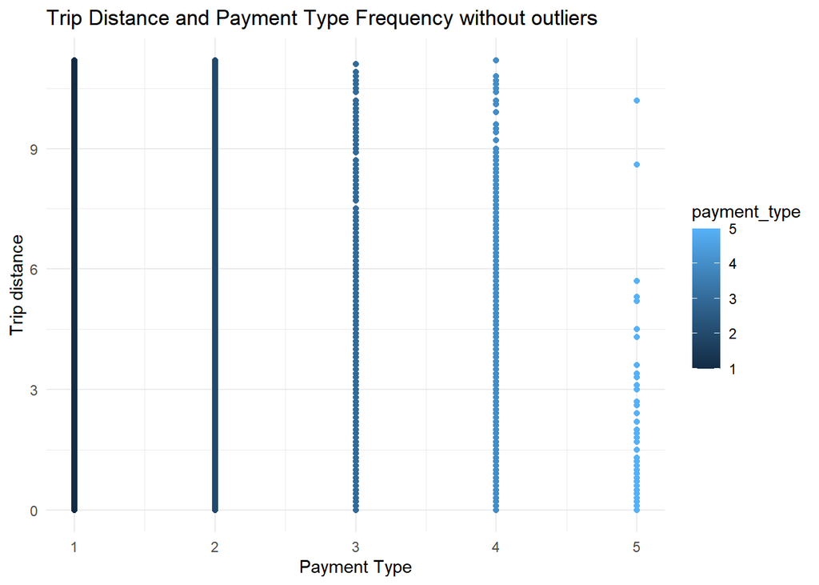

```r
#Remove trip_distance outliers
new_clean_tripdata_df <- subset(clean_tripdata_df, tot_dist_outlier <= 3)

plot_without_outliers<- ggplot(data = new_clean_tripdata_df, aes(x = payment_type, fill = payment_type, y = trip_distance, color = payment_type)) +
  geom_point() +
  labs(title = "Trip Distance and Payment Type Frequency without outliers",
       x = "Payment Type", y = "Trip distance") +
  theme_minimal()
plot_without_outliers
```

The number of trips left after data clean up was done are: “1031555”.

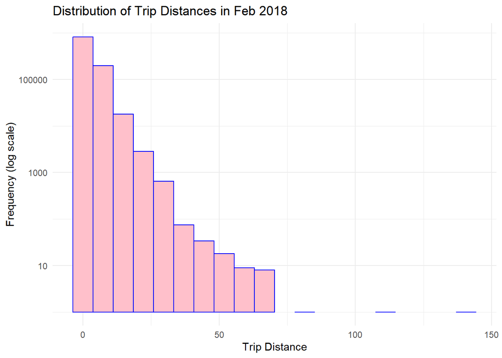

```r
# Visualize trip_distance with histogram
# Remove the scientific notion from the plot for better readability
options(scipen=999)
histog2018 <- ggplot(data = tripdata_df, aes(x = trip_distance)) +
  geom_histogram(na.rm = TRUE,bins = 20, fill = "pink", color = "blue") +
  labs(title = "Distribution of Trip Distances in Feb 2018", x = "Trip Distance",
       y = "Frequency (log scale)") +
  scale_y_log10() +
  theme_minimal()
histog2018
```

```r
# Get skewness
skewness<- skewness(tripdata_df$trip_distance, na.rm = TRUE)

# Look at the possibilities
if (skewness > 0) {
  cat("\n, Positively skewed data with tail to the right.")
} else if (skewness < 0) {
  cat("\n, Negatively skewed data with tail to the left.")
} else {
  cat("\n, Symmetric data.\n")
}
```

```
##
## , Positively skewed data with tail to the right.
```

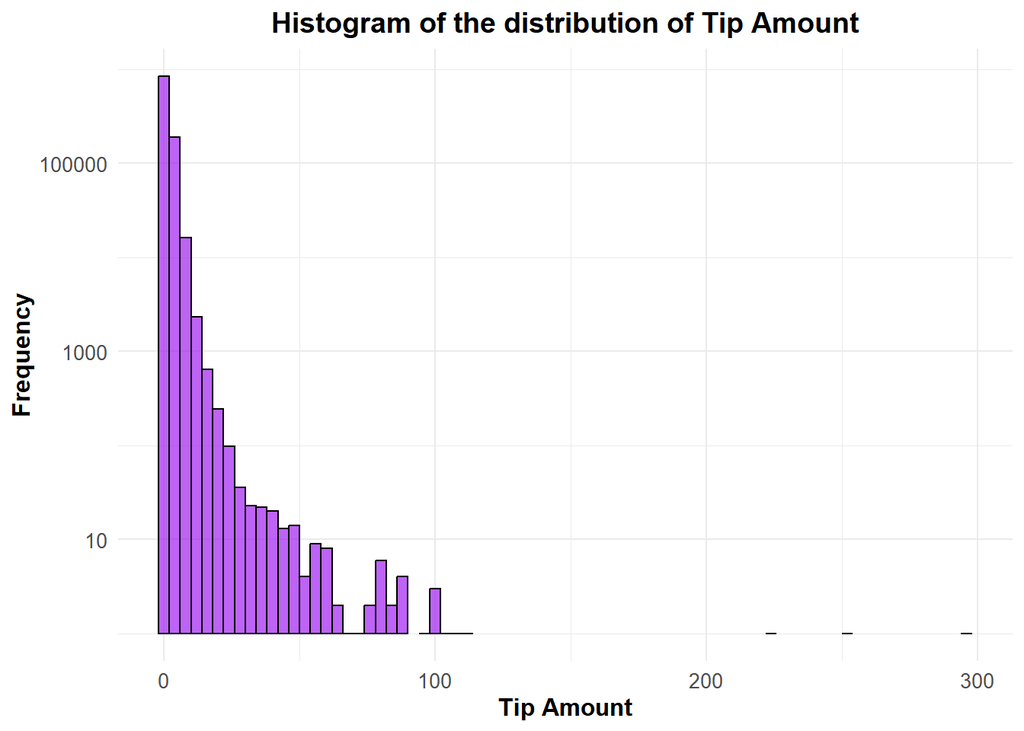

```r
# Histogram for tip_amount before data cleaning
ggplot(tripdata_df, aes(x = tip_amount)) +
  geom_histogram(color = 'black', fill = 'purple', bins = 35, binwidth = 4, alpha = 0.7) +
  labs(title = "Histogram of the distribution of Tip Amount", x = "Tip Amount", y = "Frequency") +
  scale_y_log10() +
  theme_minimal() +
  theme(axis.text = element_text(size = 10),
        axis.title = element_text(size = 12, face = "bold"),
        plot.title = element_text(size = 14, face = "bold", hjust = 0.5))
```

Here we can see the distribution of the trip amount and trip distance with colored histograms.

### 1.5. Distribution of variables.

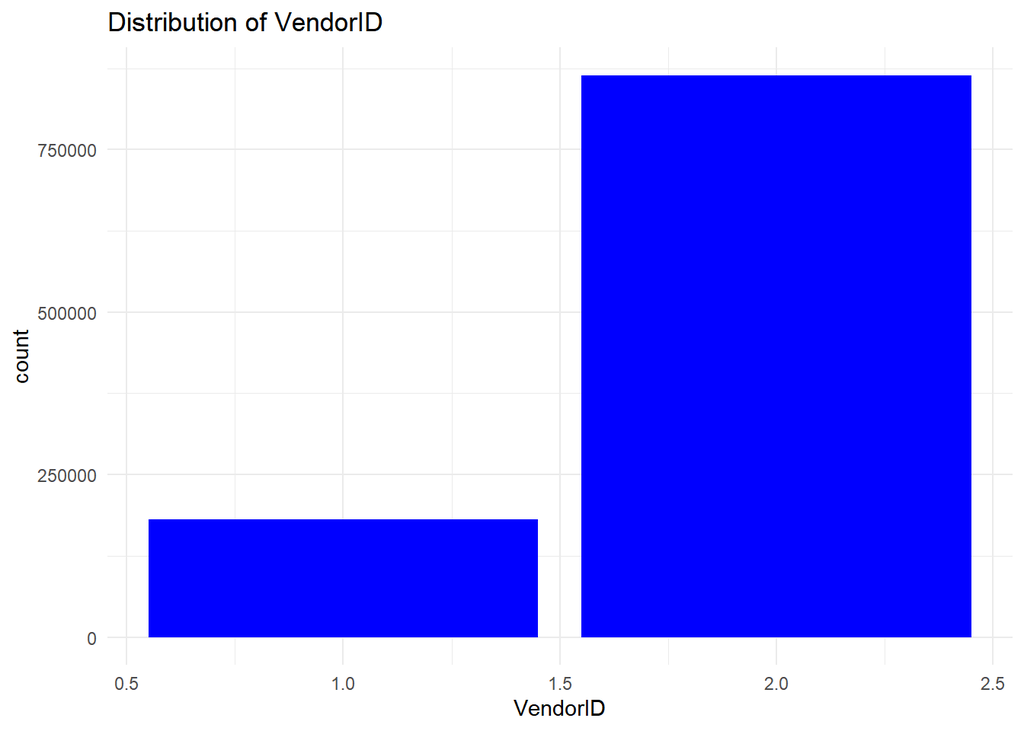

```r
ggplot(tripdata_df, aes(VendorID)) +
  geom_bar(fill = "blue") +
  labs(title = "Distribution of VendorID") +
  theme_minimal()
```

Vendor ID 2 occurs more frequently than Vendor ID 1.

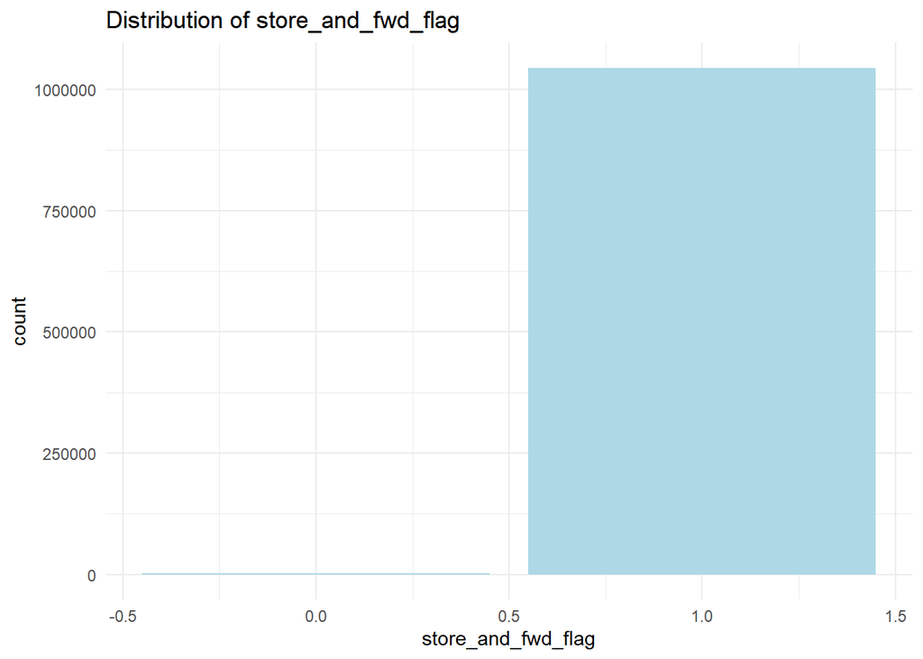

```r
ggplot(tripdata_df, aes(store_and_fwd_flag)) +
  geom_bar(fill = "lightblue") +
  labs(title = "Distribution of store_and_fwd_flag") +
  theme_minimal()
```

It seems that the Y value in this data has a zero value, it was probably omitted while recording the data.

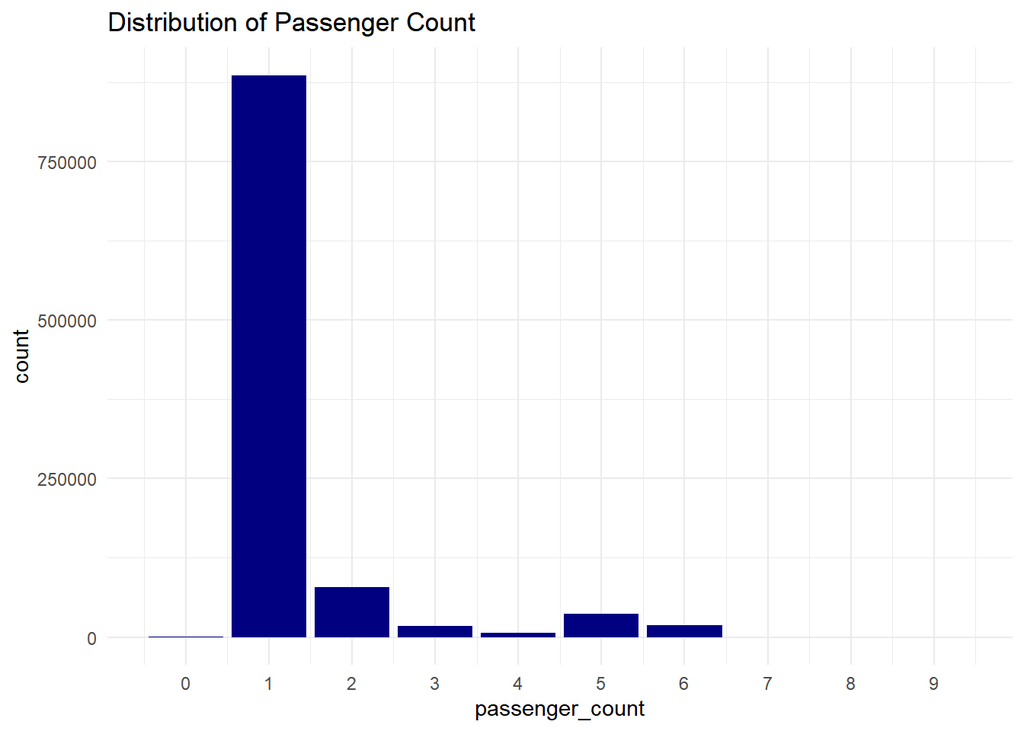

```r
ggplot(tripdata_df, aes(passenger_count)) +
  geom_bar(fill = "navyblue") +
  labs(title = "Distribution of Passenger Count") +
  scale_x_continuous(breaks = seq(0, 9, 1)) +
  theme_minimal()
```

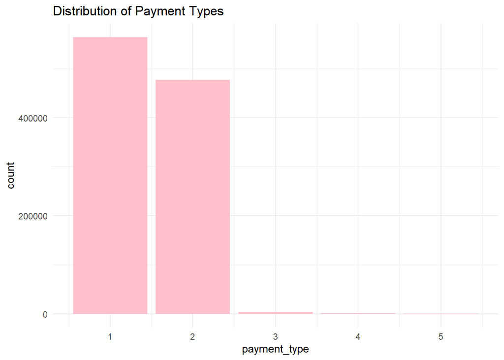

```r
ggplot(tripdata_df, aes(payment_type)) +
  geom_bar(fill = "pink") +
  labs(title = "Distribution of Payment Types ") +
  theme_minimal()
```

This plot shows the frequency of 5 payments types usage to pay taxi fare. According to this visualization, the credit card is the most popular and cash is the second most common payment method.

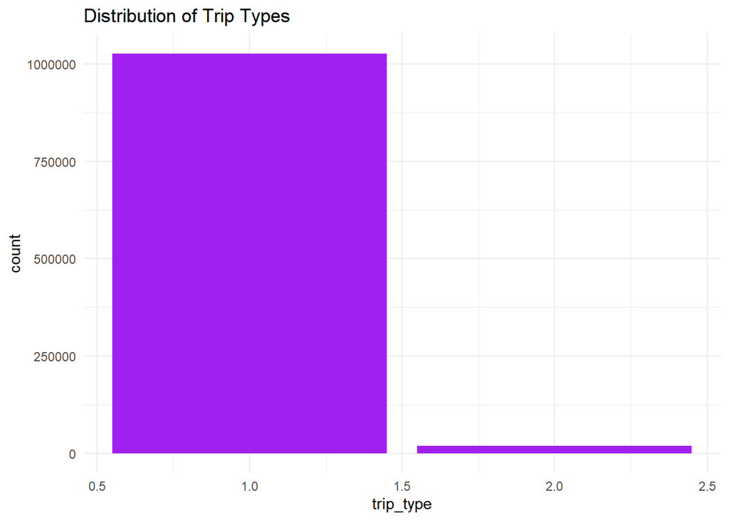

```r
ggplot(tripdata_df, aes(trip_type)) +
  geom_bar(fill = "purple") +
  labs(title = "Distribution of Trip Types") +
  theme_minimal()
```

The plot shows street hail is the most popular form of trip type.

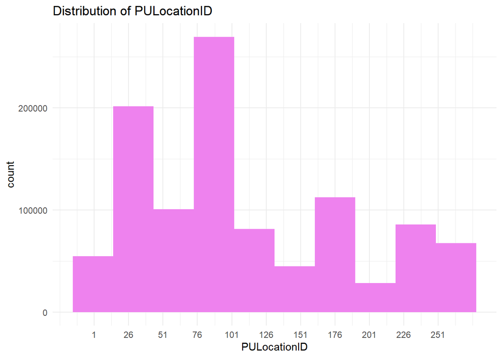

```r
ggplot(tripdata_df, aes(x = PULocationID)) +
  geom_histogram(bins = 10, fill = "violet") +
  labs(title = "Distribution of PULocationID") +
  scale_x_continuous(breaks = seq(min(tripdata_df$PULocationID), max(tripdata_df$PULocationID), 25)) +
  theme_minimal()
```

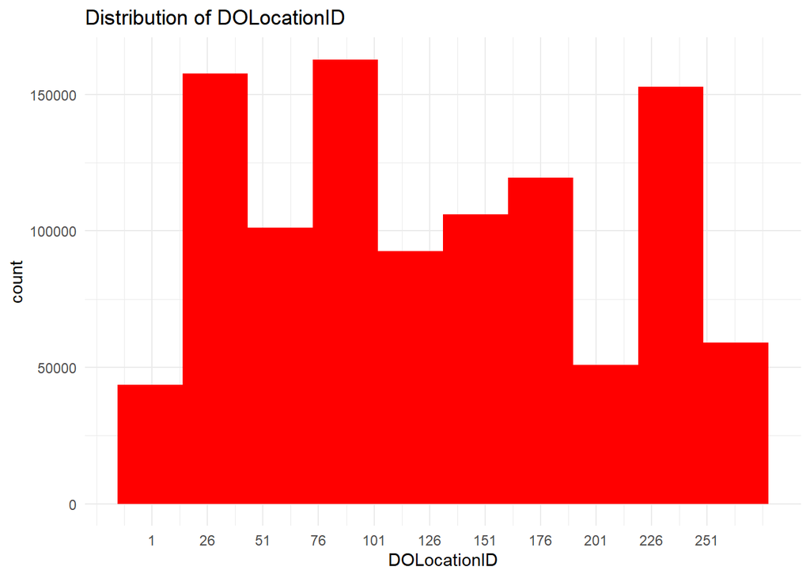

```r
ggplot(tripdata_df, aes(x = DOLocationID)) +
  geom_histogram(bins = 10, fill = "red") +
  labs(title = "Distribution of DOLocationID") +
  scale_x_continuous(breaks = seq(min(tripdata_df$DOLocationID), max(tripdata_df$DOLocationID), 25)) +
  theme_minimal()
```

This variable is randomly distributed.

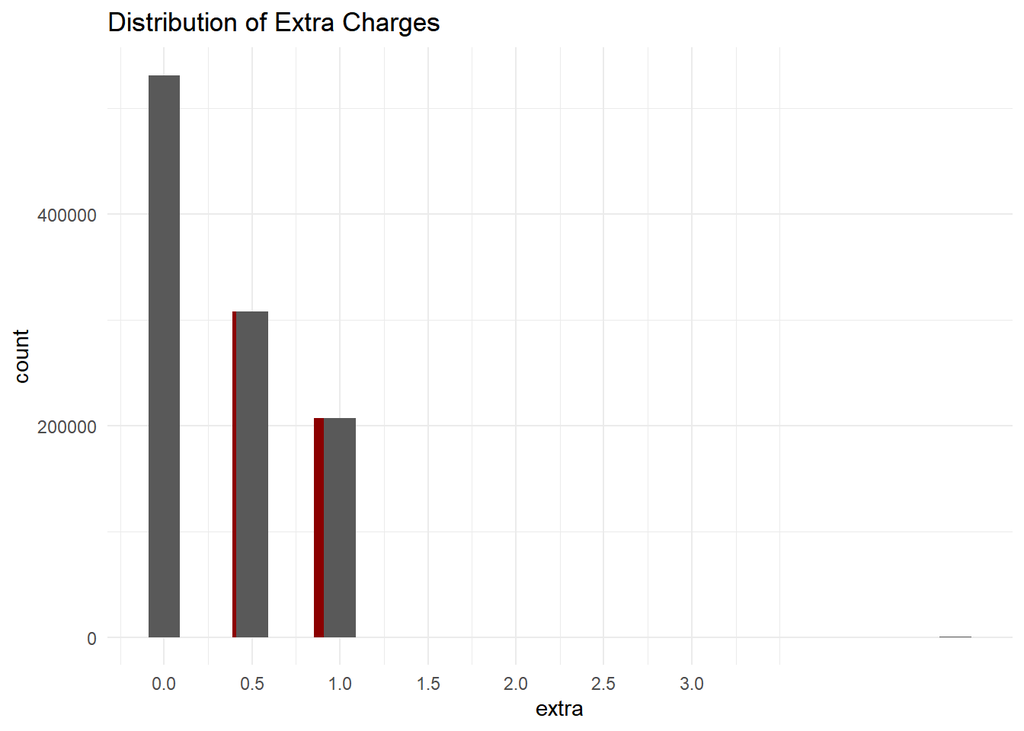

```r
ggplot(tripdata_df, aes(x = extra)) +
  geom_histogram(bins = 30, fill = "darkred") +
  labs(title = "Distribution of Extra Charges") +
  scale_x_continuous(breaks = seq(-3.0, 3.0, 0.5)) +
  geom_bar() +
  theme_minimal()
```

```r
# cat("From the above plot, it can be observed that the additional charge (extra) is very nominal.\n")
```

The graph shows that lots of extra charges are taken from cab users, the data dictionary identifies these charges are in relation to $1 or $0.50 rush hour charges, as well as overnight charges for late trips.

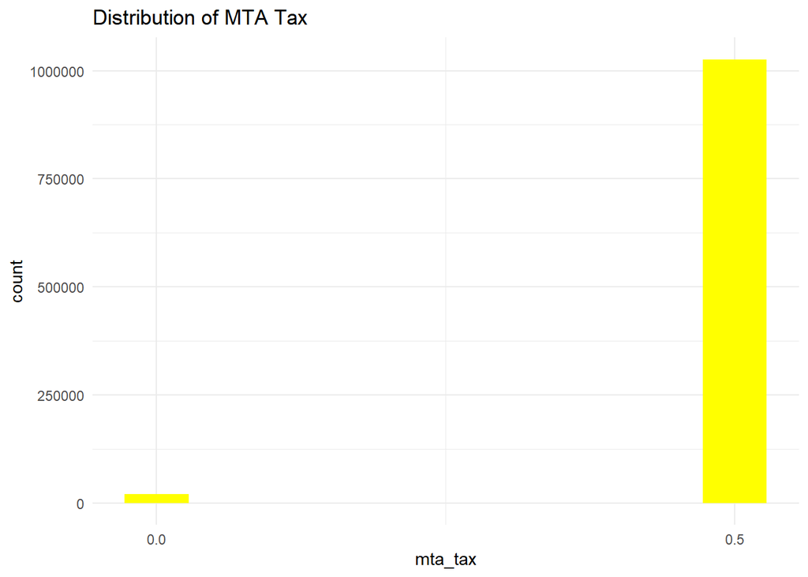

```r
ggplot(tripdata_df, aes(x = mta_tax)) +
  geom_histogram(bins = 10, fill = "yellow") +
  labs(title = "Distribution of MTA Tax ") +
  scale_x_continuous(breaks = seq(min(tripdata_df$mta_tax), max(tripdata_df$mta_tax), 0.5)) +
  theme_minimal()
```

Most cabs pay MTA tax of $0.5 per ride.

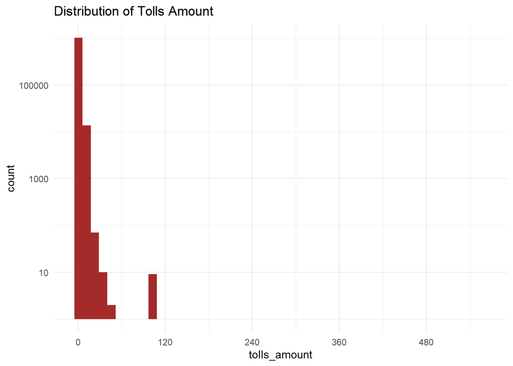

```r
ggplot(tripdata_df, aes(x = tolls_amount)) +
  geom_histogram(bins = 50, fill = "brown") +
  labs(title = "Distribution of Tolls Amount") +
  scale_x_continuous(breaks = seq(min(tripdata_df$tolls_amount), max(tripdata_df$tolls_amount), 120)) +
  scale_y_log10() +
  theme_minimal()
```

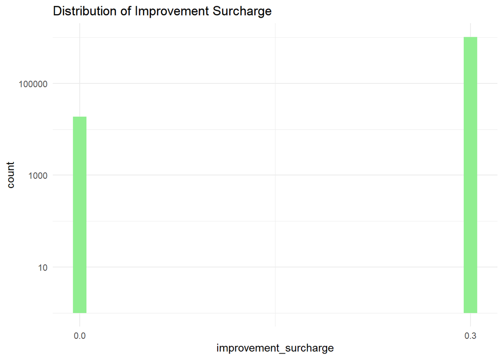

```r
ggplot(tripdata_df, aes(x = improvement_surcharge)) +
  geom_histogram(fill = "lightgreen") +
  labs(title = "Distribution of Improvement Surcharge") +
  scale_x_continuous(breaks = seq(min(tripdata_df$improvement_surcharge), max(tripdata_df$improvement_surcharge), 0.3)) +
  scale_y_log10() +
  theme_minimal()
```

The Graph shows surcharge is mostly around 0.3. Consultation with the data dictionary shows that these surcharges are triggered based on hailed trips at the flag drop.

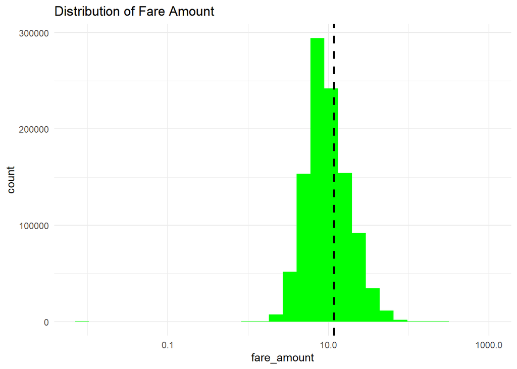

```r
ggplot(tripdata_df, aes(x = fare_amount)) +
  geom_histogram(bins = 30, fill = "green") +
  labs(title = "Distribution of Fare Amount") +
  geom_vline(aes(xintercept = mean(fare_amount, na.rm = TRUE)), color ="black",linetype= "dashed", size = 1) +
  scale_x_log10() +
  theme_minimal()
```

This visualization was made possible by transforming this variable to numeric type, which enabled us to look at the distribution through the ggplot2 package.This variable is mostly normally distributed, but has a slight skew to the left.

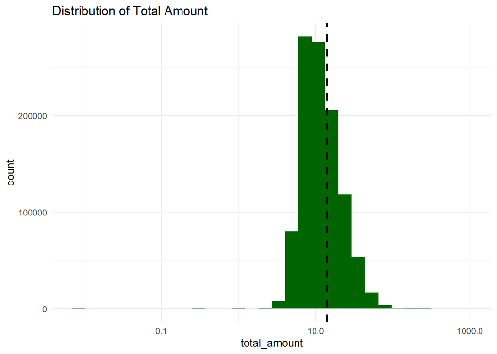

```r
ggplot(tripdata_df, aes(x = total_amount)) +
  geom_histogram(bins = 30, fill = "darkgreen") +
  labs(title = "Distribution of Total Amount") +
  geom_vline(aes(xintercept = mean(tripdata_df$total_amount, na.rm = TRUE)), color = "black",linetype = "dashed", size = 1) +
  scale_x_log10() +
  theme_minimal()
```

This visualization was made possible by transforming this variable to numeric type, which enabled us to look at the distribution through ggplot2 package. This variable is mostly normally distributed, but has a slight skew to the left.

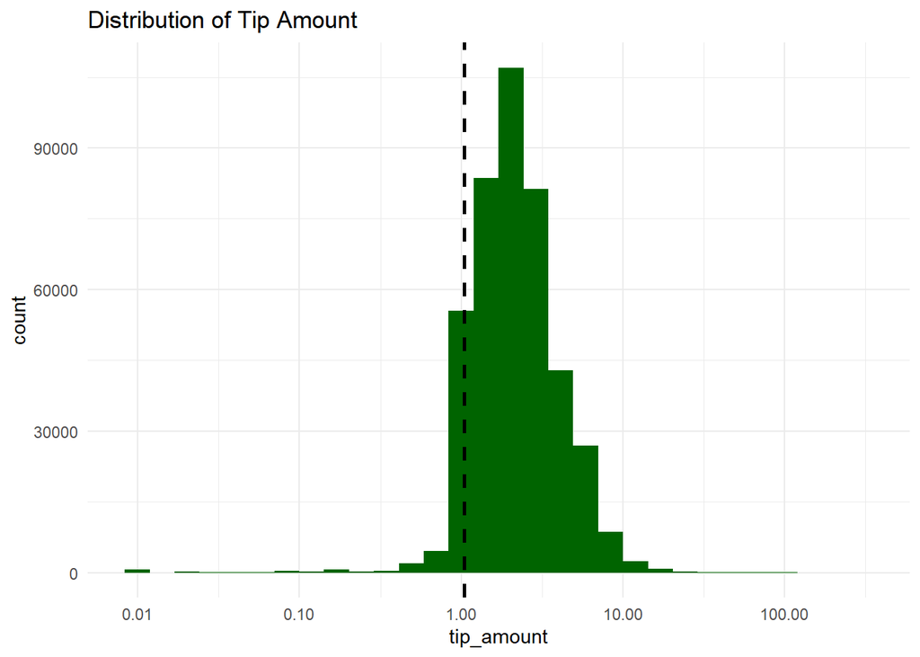

```r
ggplot(tripdata_df, aes(x = tip_amount)) +
  geom_histogram(bins = 30, fill = "darkgreen") +
  labs(title = "Distribution of Tip Amount") +
  geom_vline(aes(xintercept = mean(tripdata_df$tip_amount, na.rm = TRUE)), color = "black", linetype = "dashed", size = 1) +
  scale_x_log10() +
  theme_minimal()
```

This variable is skewed to the right.  
The date columns will not be visualized as we do not consider them of much importance for this analysis.

### 1.6. Variable correlation.

```r
str(tripdata_df)
```

```
## 'data.frame':    1045999 obs. of  20 variables:
##  $ VendorID             : num  2 2 2 2 2 2 2 2 2 2 ...
##  $ lpep_pickup_datetime : chr  "1/1/2018 0:18" "1/1/2018 0:30" "1/1/2018 0:07" "1/1/2018 0:32" ...
##  $ lpep_dropoff_datetime: chr  "1/1/2018 0:24" "1/1/2018 0:46" "1/1/2018 0:19" "1/1/2018 0:33" ...
##  $ store_and_fwd_flag   : num  1 1 1 1 1 1 1 1 1 1 ...
##  $ RatecodeID           : num  1 1 1 1 1 1 1 1 1 1 ...
##  $ PULocationID         : num  236 43 74 255 255 189 189 129 226 145 ...
##  $ DOLocationID         : num  236 42 152 255 161 65 225 82 7 129 ...
##  $ passenger_count      : num  5 5 1 1 1 5 5 1 1 2 ...
##  $ trip_distance        : num  0.7 3.5 2.14 0.03 5.63 1.71 3.45 1.61 1.87 4.12 ...
##  $ fare_amount          : num  6 14.5 10 3 21 8.5 14.5 10 7.5 16.5 ...
##  $ extra                : num  0.5 0.5 0.5 0.5 0.5 0.5 0.5 0.5 0.5 0.5 ...
##  $ mta_tax              : num  0.5 0.5 0.5 0.5 0.5 0.5 0.5 0.5 0.5 0.5 ...
##  $ tip_amount           : num  0 0 0 0 0 0 3.16 0 0 0 ...
##  $ tolls_amount         : num  0 0 0 0 0 0 0 0 0 0 ...
##  $ improvement_surcharge: num  0.3 0.3 0.3 0.3 0.3 0.3 0.3 0.3 0.3 0.3 ...
##  $ total_amount         : num  7.3 15.8 11.3 4.3 22.3 ...
##  $ payment_type         : num  2 2 2 2 2 2 1 2 2 2 ...
##  $ trip_type            : num  1 1 1 1 1 1 1 1 1 1 ...
##  $ tot_tip_outlier      : num  0.554 0.554 0.554 0.554 0.554 ...
##  $ tot_dist_outlier     : num  0.691 0.292 0.185 0.926 1.04 ...
```

```r
# Variables for correlation
vars4cor <- clean_tripdata_df %>%
  select(-lpep_pickup_datetime, -lpep_dropoff_datetime, -tot_tip_outlier, -tot_dist_outlier)

# Displaying the correlation matrix for all variables
cor(vars4cor)
```

```
##                           VendorID store_and_fwd_flag    RatecodeID
## VendorID               1.000000000      0.08812276527 -0.0177645813
## store_and_fwd_flag     0.088122765      1.00000000000 -0.0007434114
## RatecodeID            -0.017764581     -0.00074341140  1.0000000000
## PULocationID           0.008532604      0.00004135114  0.0579343253
## DOLocationID          -0.001153091     -0.00249875091  0.0236251569
## passenger_count        0.091729748      0.00765979747 -0.0090591142
## trip_distance          0.029274930      0.00313373068  0.0382084103
## fare_amount            0.039112980      0.00323831926  0.0926946221
## extra                 -0.003870526     -0.00702706387 -0.1112806312
## mta_tax                0.012535792     -0.00012747378 -0.9379946791
## tip_amount            -0.041297937      0.00203726614 -0.0519299558
## tolls_amount           0.001968680      0.00004486524  0.0153931468
## improvement_surcharge  0.011571509      0.00026918893 -0.9264557125
## total_amount           0.032000391      0.00317006646  0.0649534150
## payment_type          -0.059459304     -0.01126093111  0.0483908975
## trip_type             -0.011561069      0.00111337646  0.9387878970
##                         PULocationID DOLocationID passenger_count trip_distance
## VendorID               0.00853260432 -0.001153091    0.0917297479   0.029274930
## store_and_fwd_flag     0.00004135114 -0.002498751    0.0076597975   0.003133731
## RatecodeID             0.05793432531  0.023625157   -0.0090591142   0.038208410
## PULocationID           1.00000000000  0.162774021    0.0163946605   0.052686140
## DOLocationID           0.16277402105  1.000000000    0.0066495144   0.083876872
## passenger_count        0.01639466051  0.006649514    1.0000000000   0.002067827
## trip_distance          0.05268614018  0.083876872    0.0020678271   1.000000000
## fare_amount            0.04358315406  0.076054763    0.0026827850   0.895230445
## extra                  0.01751320228 -0.009302610    0.0108698440  -0.056749548
## mta_tax               -0.05850569419 -0.021583628    0.0115283406  -0.021623545
## tip_amount             0.01560715137  0.090390325    0.0031136884   0.192118016
## tolls_amount           0.01542050406  0.015506630    0.0088335635   0.195024816
## improvement_surcharge -0.05822408360 -0.022096152    0.0111601057  -0.019023760
## total_amount           0.04514095352  0.086132764    0.0047749066   0.888388573
## payment_type          -0.00632241718 -0.036204039   -0.0001340133  -0.111902231
## trip_type              0.05599681189  0.019708798   -0.0108331616   0.020776940
##                        fare_amount        extra       mta_tax   tip_amount
## VendorID               0.039112980 -0.003870526  0.0125357921 -0.041297937
## store_and_fwd_flag     0.003238319 -0.007027064 -0.0001274738  0.002037266
## RatecodeID             0.092694622 -0.111280631 -0.9379946791 -0.051929956
## PULocationID           0.043583154  0.017513202 -0.0585056942  0.015607151
## DOLocationID           0.076054763 -0.009302610 -0.0215836280  0.090390325
```

[output cut: 30 more lines]

```
## store_and_fwd_flag    -0.0112609311  0.001113376
## RatecodeID             0.0483908975  0.938787897
## PULocationID          -0.0063224172  0.055996812
## DOLocationID          -0.0362040388  0.019708798
## passenger_count       -0.0001340133 -0.010833162
## trip_distance         -0.1119022312  0.020776940
## fare_amount           -0.1247521765  0.066012063
## extra                  0.0014102147 -0.110700403
## mta_tax               -0.0511635629 -0.970412847
## tip_amount            -0.6082876282 -0.053287276
## tolls_amount          -0.0107078886  0.004374055
## improvement_surcharge -0.0502140987 -0.979132815
## total_amount          -0.2133554488  0.038143869
## payment_type           1.0000000000  0.049956236
## trip_type              0.0499562365  1.000000000
```

```r
# Correlation matrix to see the relation of tip_amount with other variables
cor(vars4cor, vars4cor$tip_amount)
```

```
##                               [,1]
## VendorID              -0.041297937
## store_and_fwd_flag     0.002037266
## RatecodeID            -0.051929956
## PULocationID           0.015607151
## DOLocationID           0.090390325
## passenger_count        0.003113688
## trip_distance          0.192118016
## fare_amount            0.179341442
## extra                  0.040240477
## mta_tax                0.055878943
## tip_amount             1.000000000
## tolls_amount           0.047108806
## improvement_surcharge  0.055420081
## total_amount           0.329922719
## payment_type          -0.608287628
## trip_type             -0.053287276
```

From the correlation matrix, we compare trip amount with other variables:  
Negative correlation is seen with VendorID, RatecodeID, payment_type, trip_type.  
The rest of the variables are positively correlated to trip amount.  
The highest correlation between trip amount is total amount followed by trip distance and fare amount.

### 1.7. Feature Selection.

```r
str(tripdata_df)
```

```
## 'data.frame':    1045999 obs. of  20 variables:
##  $ VendorID             : num  2 2 2 2 2 2 2 2 2 2 ...
##  $ lpep_pickup_datetime : chr  "1/1/2018 0:18" "1/1/2018 0:30" "1/1/2018 0:07" "1/1/2018 0:32" ...
##  $ lpep_dropoff_datetime: chr  "1/1/2018 0:24" "1/1/2018 0:46" "1/1/2018 0:19" "1/1/2018 0:33" ...
##  $ store_and_fwd_flag   : num  1 1 1 1 1 1 1 1 1 1 ...
##  $ RatecodeID           : num  1 1 1 1 1 1 1 1 1 1 ...
##  $ PULocationID         : num  236 43 74 255 255 189 189 129 226 145 ...
##  $ DOLocationID         : num  236 42 152 255 161 65 225 82 7 129 ...
##  $ passenger_count      : num  5 5 1 1 1 5 5 1 1 2 ...
##  $ trip_distance        : num  0.7 3.5 2.14 0.03 5.63 1.71 3.45 1.61 1.87 4.12 ...
##  $ fare_amount          : num  6 14.5 10 3 21 8.5 14.5 10 7.5 16.5 ...
##  $ extra                : num  0.5 0.5 0.5 0.5 0.5 0.5 0.5 0.5 0.5 0.5 ...
##  $ mta_tax              : num  0.5 0.5 0.5 0.5 0.5 0.5 0.5 0.5 0.5 0.5 ...
##  $ tip_amount           : num  0 0 0 0 0 0 3.16 0 0 0 ...
##  $ tolls_amount         : num  0 0 0 0 0 0 0 0 0 0 ...
##  $ improvement_surcharge: num  0.3 0.3 0.3 0.3 0.3 0.3 0.3 0.3 0.3 0.3 ...
##  $ total_amount         : num  7.3 15.8 11.3 4.3 22.3 ...
##  $ payment_type         : num  2 2 2 2 2 2 1 2 2 2 ...
##  $ trip_type            : num  1 1 1 1 1 1 1 1 1 1 ...
##  $ tot_tip_outlier      : num  0.554 0.554 0.554 0.554 0.554 ...
##  $ tot_dist_outlier     : num  0.691 0.292 0.185 0.926 1.04 ...
```

```r
data2model <- tripdata_df[,1:18]
model <- lm(tip_amount ~ VendorID + store_and_fwd_flag + RatecodeID +
              PULocationID + DOLocationID + passenger_count +
              trip_distance + fare_amount + extra + mta_tax +
              tolls_amount + improvement_surcharge + total_amount +
              payment_type + trip_type, data = tripdata_df)
summary(model)
```

```
##
## Call:
## lm(formula = tip_amount ~ VendorID + store_and_fwd_flag + RatecodeID +
##     PULocationID + DOLocationID + passenger_count + trip_distance +
##     fare_amount + extra + mta_tax + tolls_amount + improvement_surcharge +
##     total_amount + payment_type + trip_type, data = tripdata_df)
##
## Residuals:
##     Min      1Q  Median      3Q     Max
## -9.5631 -0.0040  0.0119  0.0439  9.7002
##
## Coefficients:
##                           Estimate   Std. Error   t value             Pr(>|t|)
## (Intercept)            0.110320421  0.018374633     6.004    0.000000001926344
## VendorID              -0.037659817  0.000598744   -62.898 < 0.0000000000000002
## store_and_fwd_flag     0.006180445  0.005568018     1.110             0.267004
## RatecodeID             0.011238264  0.001311766     8.567 < 0.0000000000000002
## PULocationID          -0.000026424  0.000003062    -8.630 < 0.0000000000000002
## DOLocationID           0.000040655  0.000002956    13.755 < 0.0000000000000002
## passenger_count       -0.001562787  0.000215698    -7.245    0.000000000000432
## trip_distance          0.002585584  0.000185263    13.956 < 0.0000000000000002
## fare_amount           -0.967076149  0.000154175 -6272.578 < 0.0000000000000002
## extra                 -0.947460354  0.000593422 -1596.604 < 0.0000000000000002
## mta_tax               -1.040094527  0.016453059   -63.216 < 0.0000000000000002
## tolls_amount          -0.967027425  0.000288506 -3351.844 < 0.0000000000000002
## improvement_surcharge -0.882693010  0.033150790   -26.627 < 0.0000000000000002
## total_amount           0.967106937  0.000142141  6803.867 < 0.0000000000000002
## payment_type          -0.014889671  0.000508127   -29.303 < 0.0000000000000002
## trip_type             -0.032634638  0.009348070    -3.491             0.000481
##
## (Intercept)           ***
## VendorID              ***
## store_and_fwd_flag
## RatecodeID            ***
## PULocationID          ***
## DOLocationID          ***
## passenger_count       ***
## trip_distance         ***
## fare_amount           ***
## extra                 ***
## mta_tax               ***
## tolls_amount          ***
## improvement_surcharge ***
## total_amount          ***
## payment_type          ***
## trip_type             ***
## ---
## Signif. codes:  0 '***' 0.001 '**' 0.01 '*' 0.05 '.' 0.1 ' ' 1
##
## Residual standard error: 0.2289 on 1045983 degrees of freedom
## Multiple R-squared:  0.9851, Adjusted R-squared:  0.9851
## F-statistic: 4.62e+06 on 15 and 1045983 DF,  p-value: < 0.00000000000000022
```

```r
# Remove store_and_fwd_flag
model2 <- lm(tip_amount ~ VendorID + RatecodeID +
              PULocationID + DOLocationID + passenger_count +
              trip_distance + fare_amount + extra + mta_tax +
              tolls_amount + improvement_surcharge + total_amount +
              payment_type + trip_type, data = tripdata_df)
summary(model2)
```

```
##
## Call:
## lm(formula = tip_amount ~ VendorID + RatecodeID + PULocationID +
##     DOLocationID + passenger_count + trip_distance + fare_amount +
##     extra + mta_tax + tolls_amount + improvement_surcharge +
##     total_amount + payment_type + trip_type, data = tripdata_df)
##
## Residuals:
##     Min      1Q  Median      3Q     Max
## -9.5631 -0.0040  0.0119  0.0439  9.7001
##
## Coefficients:
##                           Estimate   Std. Error   t value             Pr(>|t|)
## (Intercept)            0.116269042  0.017575738     6.615    0.000000000037094
## VendorID              -0.037601870  0.000596463   -63.041 < 0.0000000000000002
## RatecodeID             0.011234442  0.001311762     8.564 < 0.0000000000000002
## PULocationID          -0.000026424  0.000003062    -8.630 < 0.0000000000000002
## DOLocationID           0.000040647  0.000002956    13.753 < 0.0000000000000002
## passenger_count       -0.001562843  0.000215698    -7.246    0.000000000000431
## trip_distance          0.002585921  0.000185262    13.958 < 0.0000000000000002
## fare_amount           -0.967076536  0.000154175 -6272.595 < 0.0000000000000002
## extra                 -0.947464956  0.000593408 -1596.651 < 0.0000000000000002
## mta_tax               -1.040120077  0.016453044   -63.217 < 0.0000000000000002
## tolls_amount          -0.967027883  0.000288506 -3351.849 < 0.0000000000000002
## improvement_surcharge -0.882469084  0.033150180   -26.620 < 0.0000000000000002
## total_amount           0.967107185  0.000142141  6803.877 < 0.0000000000000002
## payment_type          -0.014892250  0.000508122   -29.308 < 0.0000000000000002
## trip_type             -0.032562600  0.009347846    -3.483             0.000495
##
## (Intercept)           ***
## VendorID              ***
## RatecodeID            ***
## PULocationID          ***
## DOLocationID          ***
## passenger_count       ***
## trip_distance         ***
## fare_amount           ***
## extra                 ***
## mta_tax               ***
## tolls_amount          ***
## improvement_surcharge ***
## total_amount          ***
## payment_type          ***
## trip_type             ***
## ---
## Signif. codes:  0 '***' 0.001 '**' 0.01 '*' 0.05 '.' 0.1 ' ' 1
##
## Residual standard error: 0.2289 on 1045984 degrees of freedom
## Multiple R-squared:  0.9851, Adjusted R-squared:  0.9851
## F-statistic: 4.949e+06 on 14 and 1045984 DF,  p-value: < 0.00000000000000022
```

Here features are selected based on a backward feature selection method via regression modeling. model2 was made by removing `store_and_fwd_flag` which had a high p-value of greater than 0.1. This model looks great with all features with very low p values indicating high significance. r squared and adjusted R squared are both great at 0.9851 and the F statistic is 4.949e+06 on 14 and 1045984 DF.

### 1.8. Feature Engineering.

```r
nw_trip2018dt <- tripdata_df[1:18]
# Converting date and time columns to appropriate type
nw_trip2018dt$lpep_pickup_datetime <- mdy_hm(nw_trip2018dt$lpep_pickup_datetime)
nw_trip2018dt$lpep_dropoff_datetime <- mdy_hm(nw_trip2018dt$lpep_dropoff_datetime)

# Engineer trip length
nw_trip2018dt <- nw_trip2018dt %>%
  mutate(trip_length = as.numeric(lpep_dropoff_datetime - lpep_pickup_datetime) / 60)
str(nw_trip2018dt)
```

```
## 'data.frame':    1045999 obs. of  19 variables:
##  $ VendorID             : num  2 2 2 2 2 2 2 2 2 2 ...
##  $ lpep_pickup_datetime : POSIXct, format: "2018-01-01 00:18:00" "2018-01-01 00:30:00" ...
##  $ lpep_dropoff_datetime: POSIXct, format: "2018-01-01 00:24:00" "2018-01-01 00:46:00" ...
##  $ store_and_fwd_flag   : num  1 1 1 1 1 1 1 1 1 1 ...
##  $ RatecodeID           : num  1 1 1 1 1 1 1 1 1 1 ...
##  $ PULocationID         : num  236 43 74 255 255 189 189 129 226 145 ...
##  $ DOLocationID         : num  236 42 152 255 161 65 225 82 7 129 ...
##  $ passenger_count      : num  5 5 1 1 1 5 5 1 1 2 ...
##  $ trip_distance        : num  0.7 3.5 2.14 0.03 5.63 1.71 3.45 1.61 1.87 4.12 ...
##  $ fare_amount          : num  6 14.5 10 3 21 8.5 14.5 10 7.5 16.5 ...
##  $ extra                : num  0.5 0.5 0.5 0.5 0.5 0.5 0.5 0.5 0.5 0.5 ...
##  $ mta_tax              : num  0.5 0.5 0.5 0.5 0.5 0.5 0.5 0.5 0.5 0.5 ...
##  $ tip_amount           : num  0 0 0 0 0 0 3.16 0 0 0 ...
##  $ tolls_amount         : num  0 0 0 0 0 0 0 0 0 0 ...
##  $ improvement_surcharge: num  0.3 0.3 0.3 0.3 0.3 0.3 0.3 0.3 0.3 0.3 ...
##  $ total_amount         : num  7.3 15.8 11.3 4.3 22.3 ...
##  $ payment_type         : num  2 2 2 2 2 2 1 2 2 2 ...
##  $ trip_type            : num  1 1 1 1 1 1 1 1 1 1 ...
##  $ trip_length          : num  6 16 12 1 30 10 17 13 7 18 ...
```

```r
summary(nw_trip2018dt)
```

```
##     VendorID     lpep_pickup_datetime
##  Min.   :1.000   Min.   :2009-01-01 00:02:00.00
##  1st Qu.:2.000   1st Qu.:2018-01-12 04:30:30.00
##  Median :2.000   Median :2018-01-21 18:48:00.00
##  Mean   :1.826   Mean   :2018-01-21 17:49:12.28
##  3rd Qu.:2.000   3rd Qu.:2018-01-31 18:58:00.00
##  Max.   :2.000   Max.   :2018-04-05 04:11:00.00
##  lpep_dropoff_datetime            store_and_fwd_flag   RatecodeID
##  Min.   :2009-01-01 11:16:00.00   Min.   :0.0000     Min.   :1.000
##  1st Qu.:2018-01-12 05:24:00.00   1st Qu.:1.0000     1st Qu.:1.000
##  Median :2018-01-21 19:08:00.00   Median :1.0000     Median :1.000
##  Mean   :2018-01-21 18:09:13.47   Mean   :0.9984     Mean   :1.072
##  3rd Qu.:2018-01-31 19:14:00.00   3rd Qu.:1.0000     3rd Qu.:1.000
##  Max.   :2018-04-05 04:25:00.00   Max.   :1.0000     Max.   :6.000
##   PULocationID    DOLocationID   passenger_count trip_distance
##  Min.   :  1.0   Min.   :  1.0   Min.   :0.000   Min.   :  0.000
##  1st Qu.: 49.0   1st Qu.: 61.0   1st Qu.:1.000   1st Qu.:  0.990
##  Median : 82.0   Median :129.0   Median :1.000   Median :  1.700
##  Mean   :109.9   Mean   :128.5   Mean   :1.359   Mean   :  2.668
##  3rd Qu.:166.0   3rd Qu.:192.0   3rd Qu.:1.000   3rd Qu.:  3.270
##  Max.   :265.0   Max.   :265.0   Max.   :9.000   Max.   :140.620
##   fare_amount          extra           mta_tax         tip_amount
##  Min.   :   0.00   Min.   :0.0000   Min.   :0.0000   Min.   :  0.00
##  1st Qu.:   6.00   1st Qu.:0.0000   1st Qu.:0.5000   1st Qu.:  0.00
##  Median :   9.00   Median :0.0000   Median :0.5000   Median :  0.00
##  Mean   :  11.76   Mean   :0.3462   Mean   :0.4906   Mean   :  1.04
##  3rd Qu.:  14.00   3rd Qu.:0.5000   3rd Qu.:0.5000   3rd Qu.:  1.76
##  Max.   : 999.99   Max.   :4.5000   Max.   :0.5000   Max.   :295.00
##   tolls_amount     improvement_surcharge  total_amount      payment_type
##  Min.   :  0.000   Min.   :0.0000        Min.   :   0.00   Min.   :1.000
##  1st Qu.:  0.000   1st Qu.:0.3000        1st Qu.:   7.80   1st Qu.:1.000
##  Median :  0.000   Median :0.3000        Median :  10.80   Median :1.000
##  Mean   :  0.086   Mean   :0.2946        Mean   :  14.05   Mean   :1.466
##  3rd Qu.:  0.000   3rd Qu.:0.3000        3rd Qu.:  16.80   3rd Qu.:2.000
##  Max.   :557.550   Max.   :0.3000        Max.   : 999.99   Max.   :5.000
##    trip_type      trip_length
##  Min.   :1.000   Min.   :   0.00
##  1st Qu.:1.000   1st Qu.:   6.00
##  Median :1.000   Median :  10.00
##  Mean   :1.018   Mean   :  20.02
##  3rd Qu.:1.000   3rd Qu.:  17.00
##  Max.   :2.000   Max.   :3383.00
```

```r
head(nw_trip2018dt)
```

```
##   VendorID lpep_pickup_datetime lpep_dropoff_datetime store_and_fwd_flag
## 1        2  2018-01-01 00:18:00   2018-01-01 00:24:00                  1
## 2        2  2018-01-01 00:30:00   2018-01-01 00:46:00                  1
## 3        2  2018-01-01 00:07:00   2018-01-01 00:19:00                  1
## 4        2  2018-01-01 00:32:00   2018-01-01 00:33:00                  1
## 5        2  2018-01-01 00:38:00   2018-01-01 01:08:00                  1
## 6        2  2018-01-01 00:18:00   2018-01-01 00:28:00                  1
##   RatecodeID PULocationID DOLocationID passenger_count trip_distance
## 1          1          236          236               5          0.70
## 2          1           43           42               5          3.50
## 3          1           74          152               1          2.14
## 4          1          255          255               1          0.03
## 5          1          255          161               1          5.63
## 6          1          189           65               5          1.71
##   fare_amount extra mta_tax tip_amount tolls_amount improvement_surcharge
## 1         6.0   0.5     0.5          0            0                   0.3
## 2        14.5   0.5     0.5          0            0                   0.3
## 3        10.0   0.5     0.5          0            0                   0.3
## 4         3.0   0.5     0.5          0            0                   0.3
## 5        21.0   0.5     0.5          0            0                   0.3
## 6         8.5   0.5     0.5          0            0                   0.3
##   total_amount payment_type trip_type trip_length
## 1          7.3            2         1           6
## 2         15.8            2         1          16
## 3         11.3            2         1          12
## 4          4.3            2         1           1
## 5         22.3            2         1          30
## 6          9.8            2         1          10
```

Here we have created a new feature called trip_length relying on the data in the lpep_pickup_datetime and the lpep_dropoff_datetime variables to determine how long the trip was in minutes.

### 1.9. Cross check for any issues and visualize new feature.

```r
# missing values
any(is.na(nw_trip2018dt))
```

```
## [1] FALSE
```

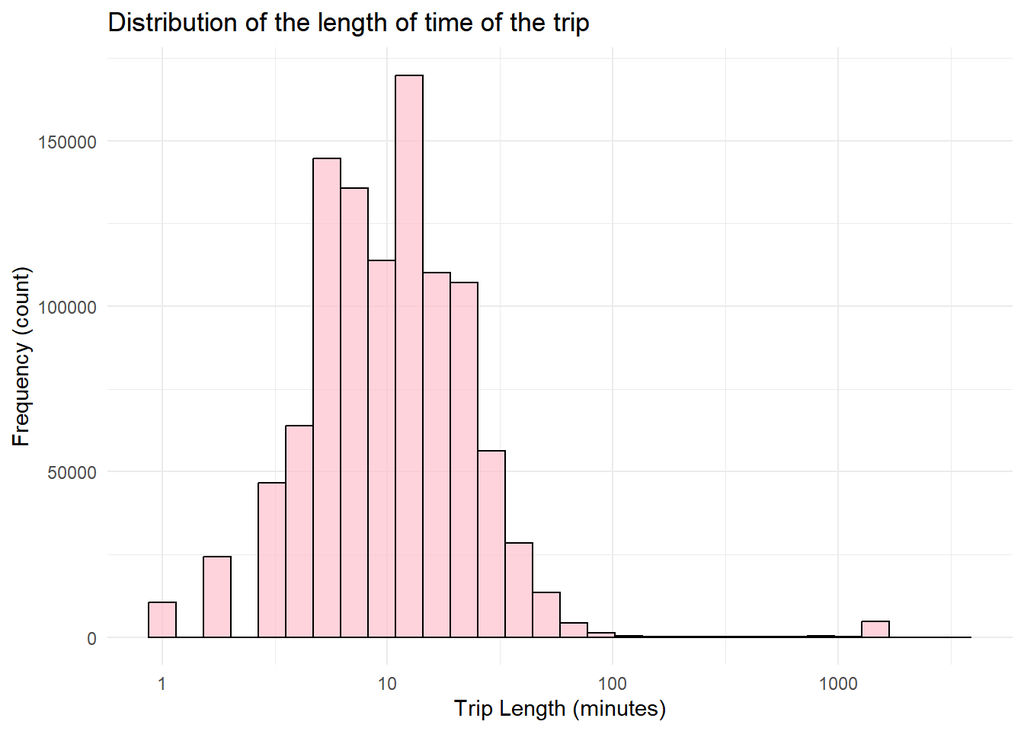

```r
# outliers in trip_length
ggplot(nw_trip2018dt, aes(x = trip_length)) +
  geom_histogram(bins = 30, color = "black", fill = "pink", alpha = 0.7) +
  labs(title = "Distribution of the length of time of the trip",
       x = "Trip Length (minutes)",
       y = "Frequency (count)") +
  scale_x_log10() +
  theme_minimal()
```

```r
# Correlation with trip amount
cor_trip_length <- cor(nw_trip2018dt$trip_length, nw_trip2018dt$tip_amount)
cor_trip_length
```

```
## [1] 0.01178633
```

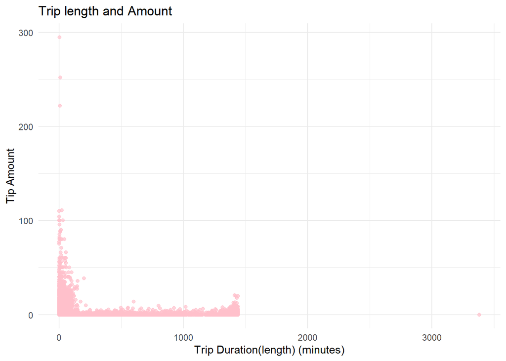

```r
# Visualize trip length with respect to trip amount
nw_trip2018dt %>%
  ggplot(aes(x = trip_length, y = tip_amount)) +
  geom_point(color = "pink", alpha = 0.7) +
  labs(title = "Trip length and Amount",
       x = "Trip Duration(length) (minutes)",
       y = "Tip Amount") +
  theme_minimal()
```

The trip length shows poor correlation with tip amount and with correlation coefficient of 0.0117863. This has been visualized with the scatter plot that can be seen above.

## Question 2 — (20 points).

CRISP-DM: Data Preparation Prepare the data for the modeling phase and handle any issues that were identified during the exploratory data analysis. At a minimum, ensure that you:  
Preprocess the data: handle missing data and outliers, perform any suitable data transformation steps, etc. Also, ensure that you filter the data. The goal is to predict the tip amount, therefore you need to ensure that you extract the data that contains this information. Hint: read the data dictionary.  
Normalize the data: perform either max-min normalization or z-score standardization on the continuous variables/features.  
Encode the data: determine if there are any categorical variables that need to be encoded and perform the encoding.  
Prepare the data for modeling: shuffle the data and split it into training and test sets. The percent split between the training and test set is your decision. However, clearly indicate the reason.

## 2.1. Feature selection.

Outliers, missing values, feature encoding, and feature transformation steps have already been carried out in the data exploration section above to ensure a good correlation matrix with reliable coefficients was obtained and the details discussed above. We will look into the important features and take off some we feel are not important. Having created the trip length we will take of the 2 date columns, and learning from the correlation that the store_and_fwd_flag has a high p value, these three variables will be taken off from the data.

```r
filtered_dt <- nw_trip2018dt %>%
  select(-lpep_pickup_datetime, -lpep_dropoff_datetime, -store_and_fwd_flag)
str(filtered_dt)
```

```
## 'data.frame':    1045999 obs. of  16 variables:
##  $ VendorID             : num  2 2 2 2 2 2 2 2 2 2 ...
##  $ RatecodeID           : num  1 1 1 1 1 1 1 1 1 1 ...
##  $ PULocationID         : num  236 43 74 255 255 189 189 129 226 145 ...
##  $ DOLocationID         : num  236 42 152 255 161 65 225 82 7 129 ...
##  $ passenger_count      : num  5 5 1 1 1 5 5 1 1 2 ...
##  $ trip_distance        : num  0.7 3.5 2.14 0.03 5.63 1.71 3.45 1.61 1.87 4.12 ...
##  $ fare_amount          : num  6 14.5 10 3 21 8.5 14.5 10 7.5 16.5 ...
##  $ extra                : num  0.5 0.5 0.5 0.5 0.5 0.5 0.5 0.5 0.5 0.5 ...
##  $ mta_tax              : num  0.5 0.5 0.5 0.5 0.5 0.5 0.5 0.5 0.5 0.5 ...
##  $ tip_amount           : num  0 0 0 0 0 0 3.16 0 0 0 ...
##  $ tolls_amount         : num  0 0 0 0 0 0 0 0 0 0 ...
##  $ improvement_surcharge: num  0.3 0.3 0.3 0.3 0.3 0.3 0.3 0.3 0.3 0.3 ...
##  $ total_amount         : num  7.3 15.8 11.3 4.3 22.3 ...
##  $ payment_type         : num  2 2 2 2 2 2 1 2 2 2 ...
##  $ trip_type            : num  1 1 1 1 1 1 1 1 1 1 ...
##  $ trip_length          : num  6 16 12 1 30 10 17 13 7 18 ...
```

### 2.2. Data Normalization.

```r
# Normalize continuous vars
working_dt <- preProcess(as.data.frame(filtered_dt), method = c("range"))
normalyzd_dt <- predict(working_dt, as.data.frame(filtered_dt))
normalyzd_dt$id <- 1:nrow(normalyzd_dt)
```

### 2.3. Data Splitting.

```r
# Get 70% of the data for training set
training_set <- normalyzd_dt %>% sample_frac(0.7)
dim(training_set)
```

```
## [1] 732199     17
```

```r
# Get the remainder for testing set
testing_set <- anti_join(normalyzd_dt, training_set, by = 'id')
dim(testing_set)
```

```
## [1] 313800     17
```

Here we determine our training and testing sets by splitting the data using a 70:30 ratio respectively.

## Question 3 — (30 points).

CRISP-DM: Modeling  
In this step you will develop the k-nn regression model. Create a function with the following name and arguments: knn.predict(data_train, data_test, k);

data_train represents the observations in the training set, data_test represents the observations from the test set, and k is the selected value of k (i.e. the number of neighbors). Perform the following logic inside the function:

Implement the k-nn algorithm and use it to predict the tip amount for each observation in the test set i.e. data_test. Note: You are not required to implement the k-nn algorithm from scratch. Therefore, this step may only involve providing the training set, the test set, and the value of k to your chosen k-nn library. Calculate the mean squared error (MSE) between the predictions from the k-nn model and the actual tip amount in the test set. The knn-predict() function should return the MSE.

### Answers:

```r
# Get MSE after modeling
knn.predict <- function(training_dt, testing_dt, k) {
  # fit model
  knn_model <- FNN::knn.reg(train = training_dt,
                            test = testing_dt,
                            y = training_dt,
                            k = k)
  # Predictions
  y_pred <- knn_model$pred
  # True values in test data
  y_test <- testing_dt[, 10]
  # MSE
  mse <- mean((y_test - y_pred)^2)
  return(mse)
}

# Get mse for our data
MSE <- knn.predict(training_set, testing_set, 5)
MSE
```

```
## [1] 0.7268592
```

The MSE for our knn model is 0.7268592 given a k value of 5. This value can be fluctuated to reduce this error in order to get the best knn model. This will be done in subsequent sections.

## Question 4 — (30 points).

CRISP-DM: Evaluation Determine the best value of k and visualize the MSE. This step requires selecting different values of k and evaluating which produced the lowest MSE. At a minimum, ensure that you perform the following:

Provide at least 20 different values of k to the knn.predict() function (along with the training set and the test set). Tip: use a loop! Use a loop to call knn.predict() 20 times and in each iteration of the loop, provide a different value of k to knn.predict(). Ensure that you save the MSE that’s returned.  
Create a line chart and plot each value of k on the x-axis and the corresponding MSE on the y-axis. Explain the chart and determine which value of k is more suitable and why.  
What are your thoughts on the model that you developed and the accuracy of its predictions? Would you advocate for its use to predict the tip amount of future trips? Explain your answer.